# R Notebook

# Statistical analysis: IGN game review

### Introduction

This R notebook uses the IGN game dataset.

The goals/questions to answer are:

- How do the sales relate to the scores, platform, genre or platform type?
- Do the scores from IGN relate to the scores from other sources? For example, reviews from users collected from GameSpot.
- What are the differences between the consoles from the same time period? For example, the consoles at the time period of PlayStation 2 vs. XBOX, PlayStation 1 vs Nintendo 64…

I will perform some statistical analysis (Anderson-Darling normality test, Wilcoxon rank sum test with continuity correction, mean via Bootstrapping) and visualizations to answer the previous set of questions.

### Data collection and Data cleaning

With python we have cleaned the data. In short, we performed the following:

- We removed the fields with empty game name (unique)
- We replaced the empty cells by NaNs
- We created a new variable which groups the different platforms into three categories: Console, Handheld System and OS.

```r
library(ggplot2)
library(gridExtra)
library(pwr)
library(gtools)
library(nortest)
library(boot)
library(plyr)
```

```r
df=read.csv("VG_final.csv")
str(df)
```

```
'data.frame':   16717 obs. of  18 variables:
 $ X              : int  0 1 2 3 4 5 6 7 8 9 ...
 $ Name           : Factor w/ 11562 levels " Beyblade Burst",..: 11058 9405 5571 11060 7410 9770 6692 11056 6695 2619 ...
 $ Platform       : Factor w/ 31 levels "2600","3DO","3DS",..: 26 12 26 26 6 6 5 26 26 12 ...
 $ Year_of_Release: num  2006 1985 2008 2009 1996 ...
 $ Genre          : Factor w/ 12 levels "Action","Adventure",..: 11 5 7 11 8 6 5 4 5 9 ...
 $ Publisher      : Factor w/ 582 levels "","10TACLE Studios",..: 371 371 371 371 371 371 371 371 371 371 ...
 $ NA_Sales       : num  41.4 29.1 15.7 15.6 11.3 ...
 $ EU_Sales       : num  28.96 3.58 12.76 10.93 8.89 ...
 $ JP_Sales       : num  3.77 6.81 3.79 3.28 10.22 ...
 $ Other_Sales    : num  8.45 0.77 3.29 2.95 1 0.58 2.88 2.84 2.24 0.47 ...
 $ Global_Sales   : num  82.5 40.2 35.5 32.8 31.4 ...
 $ Critic_Score   : num  76 NA 82 80 NA NA 89 58 87 NA ...
 $ Critic_Count   : num  51 NA 73 73 NA NA 65 41 80 NA ...
 $ User_Score     : num  8 NA 8.3 8 NA NA 8.5 6.6 8.4 NA ...
 $ User_Count     : num  322 NA 709 192 NA NA 431 129 594 NA ...
 $ Developer      : Factor w/ 1697 levels "","10tacle Studios",..: 1035 1 1035 1035 1 1 1035 1035 1035 1 ...
 $ Rating         : Factor w/ 9 levels "","AO","E","E10+",..: 3 1 3 3 1 1 3 3 3 1 ...
 $ P_type         : Factor w/ 3 levels "Console","Handheld System",..: 1 1 1 1 2 2 2 1 1 1 ...
```

### Data analysis and modelling

We want to understand whether the game scores vary from year to year. We see how the scores vary as a function of the release year.

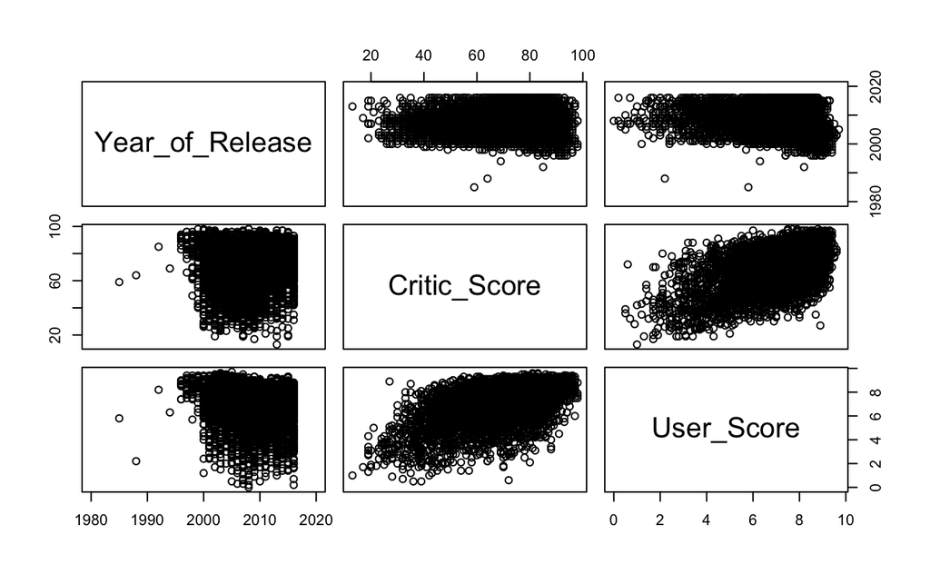

```r
pairs(~Year_of_Release+Critic_Score+User_Score,data=df)
```

We see that before 1996 there are not enough scores After that, it is really hard to see a variation of the scores with the year. We see that critic score and user score are related.

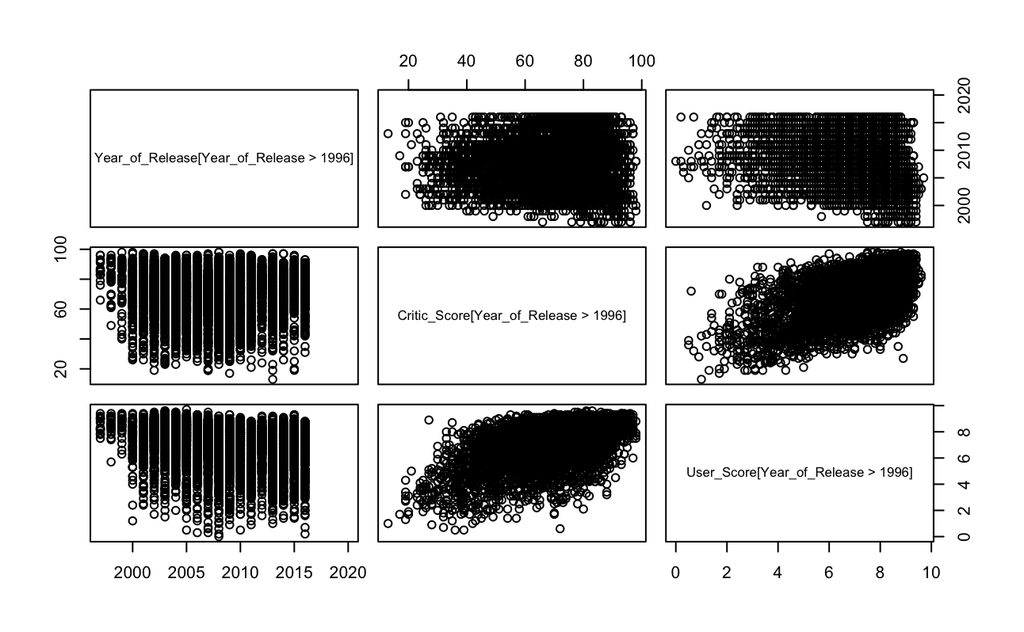

```r
pairs(~Year_of_Release[Year_of_Release>1996]+Critic_Score[Year_of_Release>1996]+User_Score[Year_of_Release>1996],data=df)
```

```r
ad.test(df[df$Year_of_Release>1996,]$Year_of_Release)
```

```
    Anderson-Darling normality test

data:  df[df$Year_of_Release > 1996, ]$Year_of_Release
A = 70.547, p-value < 2.2e-16
```

The distribution is not normal, so we perform the non-parametric Wilcox test:

```r
wilcox.test(df[df$Year_of_Release>1996,]$Year_of_Release,df[df$Year_of_Release>1996,]$User_Score, paired=FALSE, alternative='greater')
```

```
    Wilcoxon rank sum test with continuity correction

data:  df[df$Year_of_Release > 1996, ]$Year_of_Release and df[df$Year_of_Release > 1996, ]$User_Score
W = 115340000, p-value < 2.2e-16
alternative hypothesis: true location shift is greater than 0
```

We see how the mean scores varies over years. For that, we do bootstrapping to compute the mean scores.

```r
# function to compute the mean through bootstrap
boot_mean <- function(data){
samples <- replicate(length(data), mean(sample(data, size = length(data), replace = TRUE)))
  return(samples)
}
```

```r
means_year=NULL
stds_year=NULL
for (i in 1:length(unique(df$Year_of_Release))){
  if (length(na.exclude(df[df$Year_of_Release==unique(df$Year_of_Release)[i],]$User_Score))>3){
      means_year_distr=boot_mean(na.exclude(df[df$Year_of_Release==unique(df$Year_of_Release)[i],]$User_Score))
     means_year[i]=mean(means_year_distr, na.rm = TRUE)
     stds_year[i]=sd(means_year_distr, na.rm = TRUE)
  } else{
    means_year[i]=NA
    stds_year[i]=NA
  }
}
df_means_year=data.frame("years"=unique(df$Year_of_Release),"Means"=means_year,"Std"=stds_year)
plot1= ggplot(df_means_year, aes(x = years,y=Means),color='blue') +
  geom_errorbar(aes(ymin=Means-stds_year,ymax=Means+stds_year,color=Means))+labs(title = "Averages of User Scores", x = "Year", y = "Average score")+xlim(1995,2017)+ylim(6,9) +    geom_line()+geom_hline(aes(yintercept = mean(df_means_year$Means,na.rm = TRUE)),color='red',linetype="dashed", size = .4)
```

We plot the results:

```r
means_year=NULL
stds_year=NULL
for (i in 1:length(unique(df$Year_of_Release))){
  if (length(na.exclude(df[df$Year_of_Release==unique(df$Year_of_Release)[i],]$Critic_Score))>3){
      means_year_distr=boot_mean(na.exclude(df[df$Year_of_Release==unique(df$Year_of_Release)[i],]$Critic_Score))
     means_year[i]=mean(means_year_distr, na.rm = TRUE)
     stds_year[i]=sd(means_year_distr, na.rm = TRUE)
  } else{
    means_year[i]=NA
    stds_year[i]=NA
  }
}
df_means_year2=data.frame("years"=unique(df$Year_of_Release),"Means"=means_year,"Std"=stds_year)
plot2= ggplot(df_means_year2, aes(x = years,y=Means),color='blue') +
  geom_errorbar(aes(ymin=Means-stds_year,ymax=Means+stds_year,color=Means))+labs(title = "Averages of Critic Scores", x = "Year", y = "Average score") +    geom_line()+geom_hline(aes(yintercept = mean(df_means_year2$Means,na.rm = TRUE)),color='red',linetype="dashed", size = .4)+xlim(1995,2017)+ylim(60,90)
```

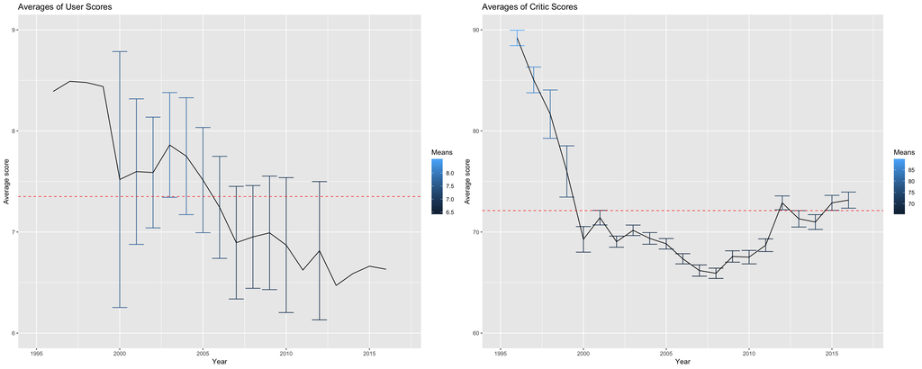

```r
grid.arrange(plot1,plot2,ncol=2)
```

### Which platform has the highest average reviews?

We compare the average scores from both users and critics, and see which platform got the better reviews.

```r
means_plat=NULL
stds_plat=NULL
for (i in 1:length(levels(df$Platform))){
  if (length(na.exclude(df[df$Platform==levels(df$Platform)[i],]$User_Score))>30){
    means_plat_distr=boot_mean(na.exclude(df[df$Platform==levels(df$Platform)[i],]$User_Score))
    means_plat[i]=mean(means_plat_distr, na.rm = TRUE)
    stds_plat[i]=sd(means_plat_distr, na.rm = TRUE)
    } else{
    means_plat[i]=NA
    stds_plat[i]=NA
  }
}
df_means_plat=data.frame("Platform"=levels(df$Platform),"Means"=means_plat,"Std"=stds_plat)
df_means_plat2=subset(df_means_plat,!(is.na(df_means_plat["Std"])))
df_means_plat3=df_means_plat2[order(df_means_plat2$Means),]
mean_of_means=('Average_of_means'=mean(df_means_plat2$Means))
plot3= ggplot(df_means_plat3, aes(x = Platform,y=Means)) +
  geom_errorbar(aes(ymin=Means-Std,ymax=Means+Std,color=Means))+labs(title = "Averages of User Scores per Platform", x = "Platform", y = "Average score") + geom_line() +geom_hline(aes(yintercept = mean_of_means),color='red',linetype="dashed", size = .4)+ylim(6,8)
```

```r
means_plat=NULL
stds_plat=NULL
for (i in 1:length(levels(df$Platform))){
  if (length(na.exclude(df[df$Platform==levels(df$Platform)[i],]$Critic_Score))>30){
    means_plat_distr=boot_mean(na.exclude(df[df$Platform==levels(df$Platform)[i],]$Critic_Score))
    means_plat[i]=mean(means_plat_distr, na.rm = TRUE)
    stds_plat[i]=sd(means_plat_distr, na.rm = TRUE)
    } else{
    means_plat[i]=NA
    stds_plat[i]=NA
  }
}
df_means_plat4=data.frame("Platform"=levels(df$Platform),"Means"=means_plat,"Std"=stds_plat)
df_means_plat5=subset(df_means_plat4,!(is.na(df_means_plat4["Std"])))
df_means_plat6=df_means_plat5[order(df_means_plat5$Means),]
mean_of_means2=('Average_of_means'=mean(df_means_plat6$Means))
plot4= ggplot(df_means_plat6, aes(x = Platform,y=Means)) +
  geom_errorbar(aes(ymin=Means-Std,ymax=Means+Std,color=Means))+labs(title = "Averages of Critic Scores per Platform", x = "Platform", y = "Average score") + geom_line() +geom_hline(aes(yintercept = mean_of_means2),color='red',linetype="dashed", size = .4)+ylim(60,80)
```

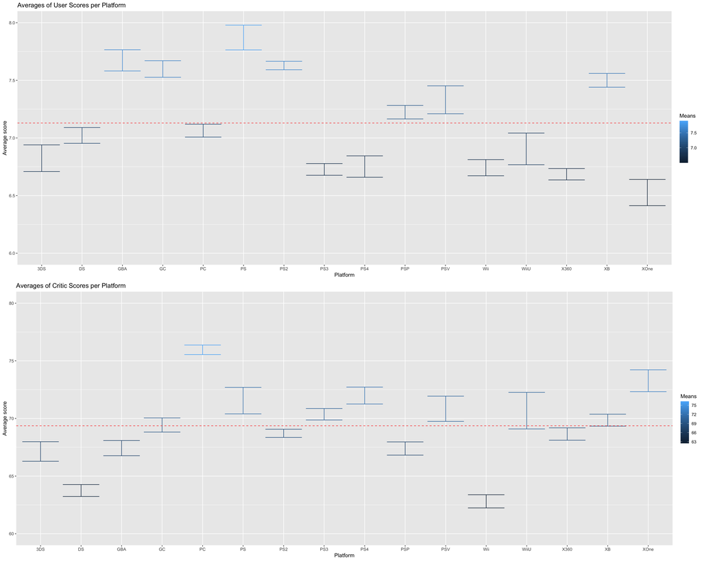

```r
grid.arrange(plot3,plot4,ncol=1)
```